# Unit 4 - Data Visualization

Jim Flynn

September 14, 2026

## Now for data viz!

- Data visualization is an incredibly important skill
  - True in private sector, public sector, academia
  - A good data visualization can tell a story all on it’s own
- First, we will go through some of the logic from the Healy chapter
- We will look at some good examples

## Why bother looking at data at all?

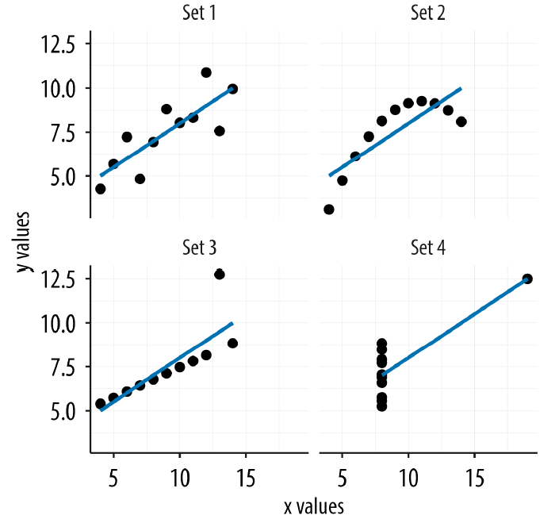

Anscombe’s Quartet

## A single outlier can drive a whole regression

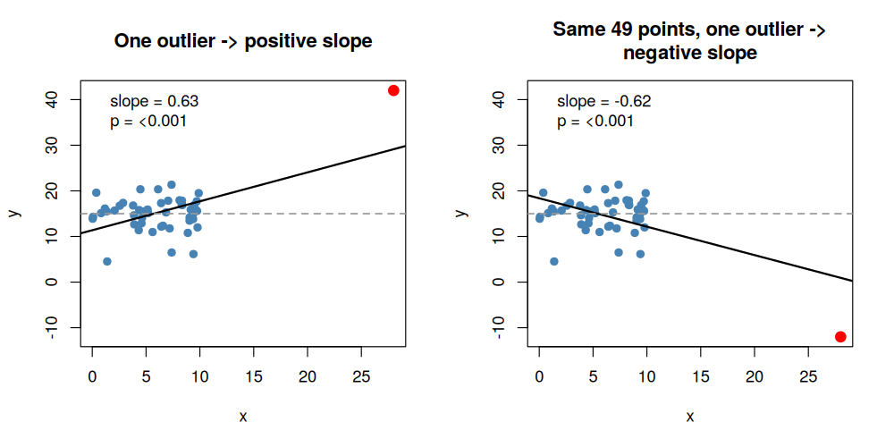

Leverage Point Demo

## What makes a figure bad?

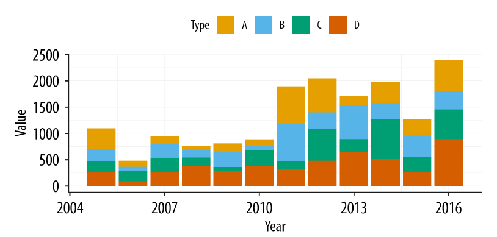

Chart Crime

- Suggestions to make this better?

## Perception is important

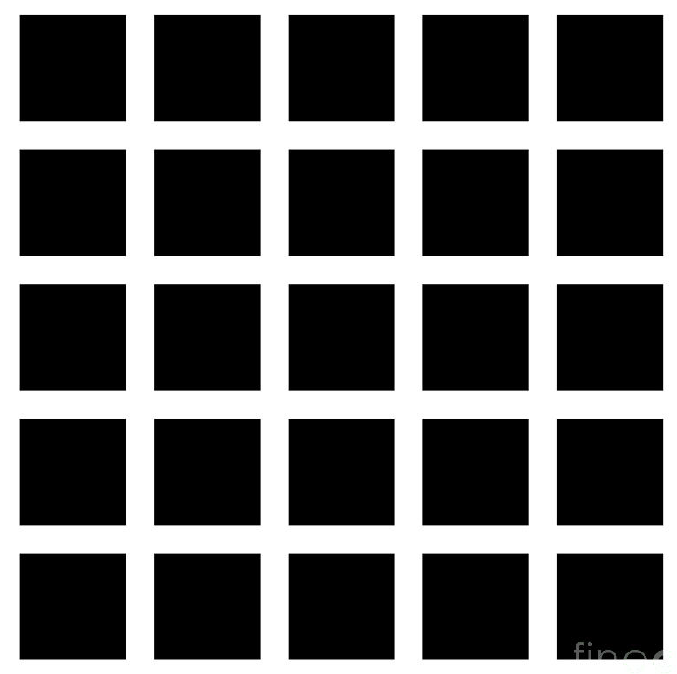

Don’t Trust Your Brain

## Repeat: Do not trust your brain

[figure not shown]

## Which one is right?

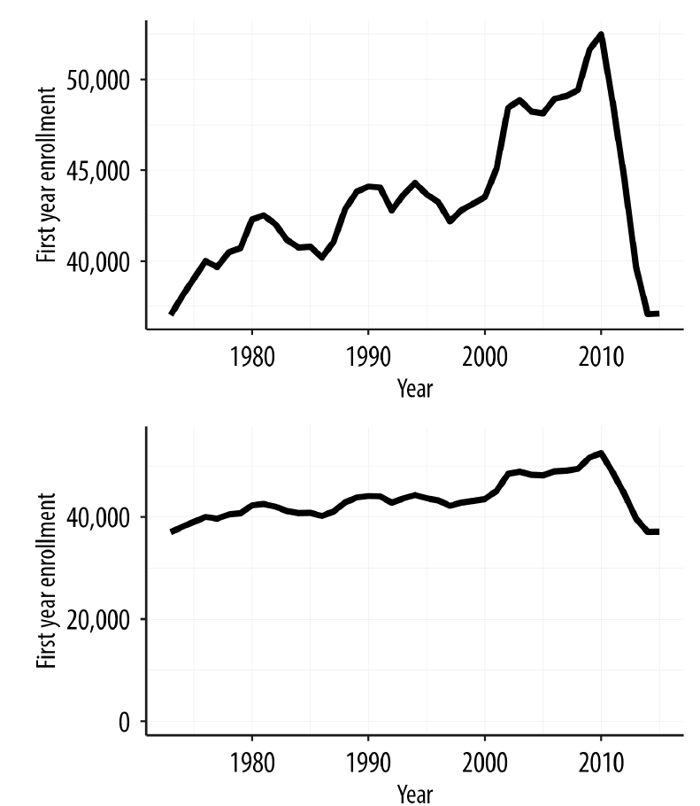

## Now let’s look at some good examples

- What is effective about these?

## Marathon bunching times

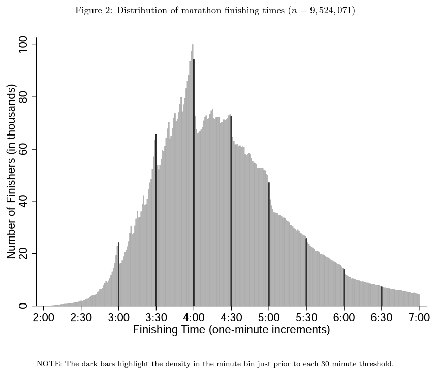

## Now a much more serious one…

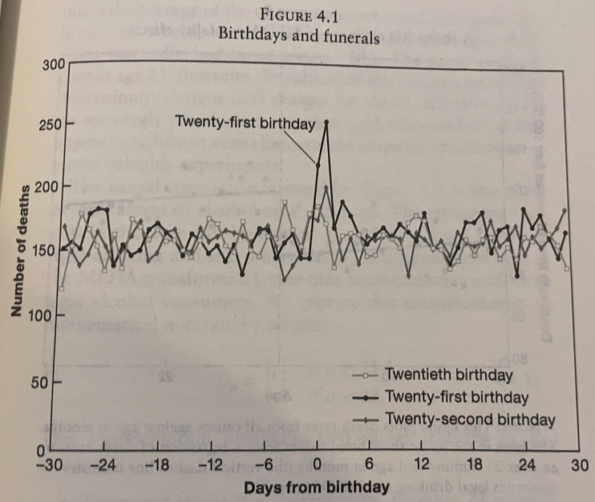

## What’s going on here?

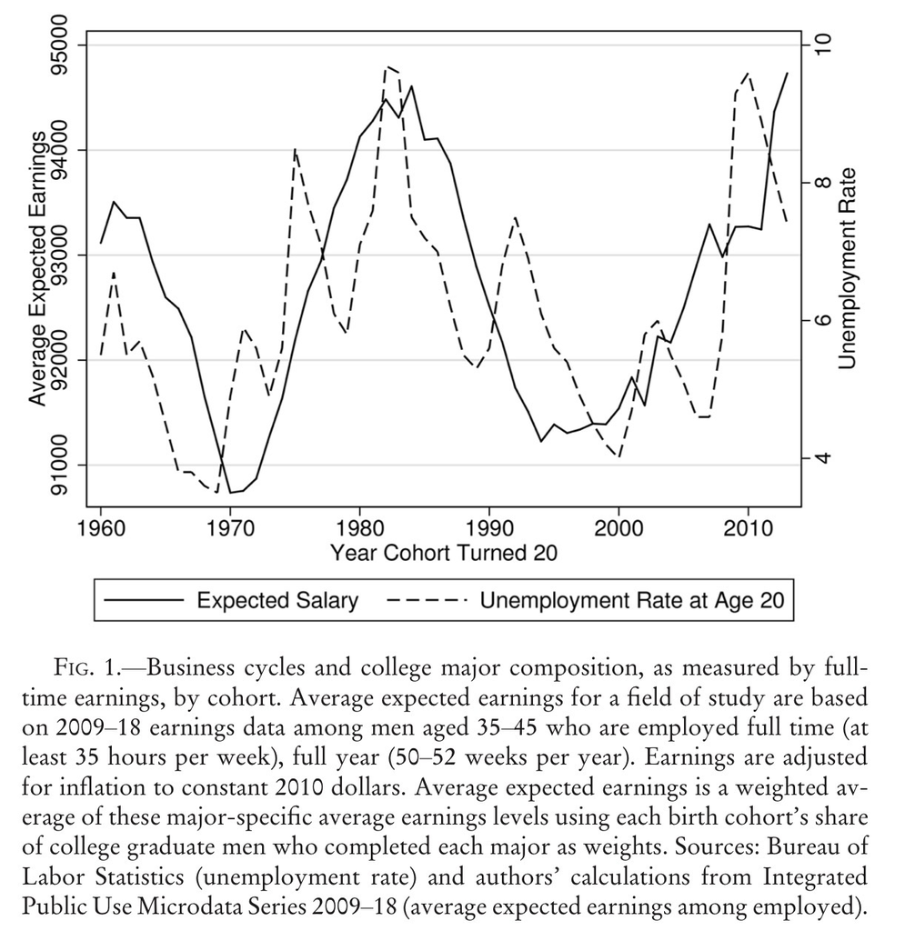

## This you?

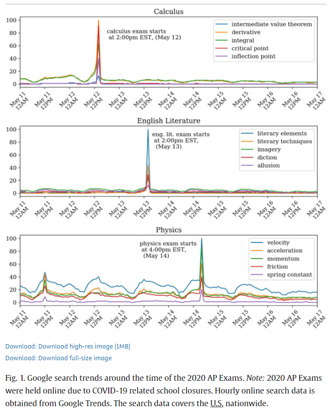

## How about this one?

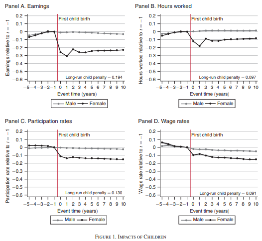

## Let’s get started

- We are going to use a package called ‘ggplot2’

```r
#install.packages('ggplot2')
library(ggplot2)
```

- This allows us to create a wide variety of graphs, with a good deal of flexibility

## Scatter plot - let’s break out some new datasets

```r
shotspot <- read.csv('shotspotter_dc_2006to2017.csv') %>%
  filter(year==2017) %>% mutate(exact_time = hour + (minute/60) + (second/3600))

nhl <- haven::read_dta("NHL Master Dataset.dta") %>%
  filter(year==2018) %>%
  mutate(log_sal = log(Salary))

covid_2020 <- haven::read_dta("covid_data.dta") %>%
  filter(year==2020 & month==12) %>%
  mutate(cases_per100k = cases/(population/1000),
         deaths_per100k = deaths/(population/1000))

abortion_distance <- haven::read_dta("myers_clinic_distance_may24.dta")
```

## Let’s look at Goals and Assists for NHL players (2018 data)

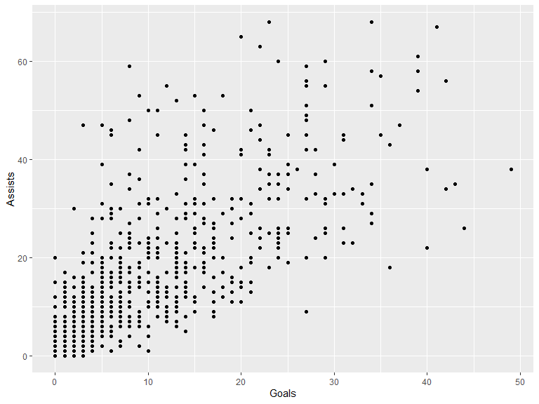

```r
ggplot(nhl, aes(x=Goals, y=Assists)) +
  geom_point()
```

## We can add a regression line with confidence intervals

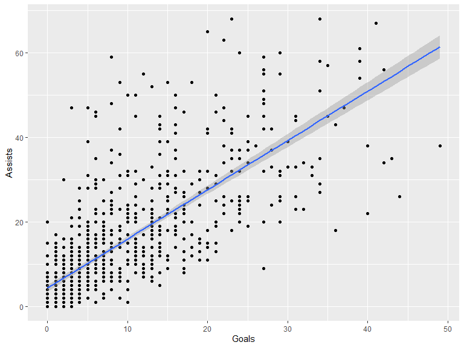

```r
ggplot(nhl, aes(x=Goals, y=Assists)) +
  geom_point() +
  geom_smooth(method="lm")
```

## What about total points versus log salary?

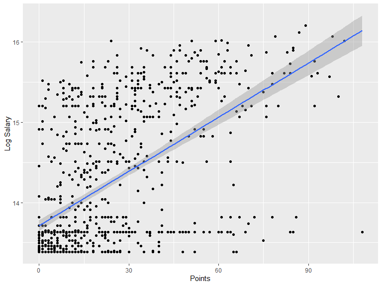

```r
ggplot(nhl, aes(x=Points, y=log_sal)) +
  geom_point() +
  geom_smooth(method="lm") +
  ylab("Log Salary")
```

## Shotspotter data - When do gunshots occur in DC?

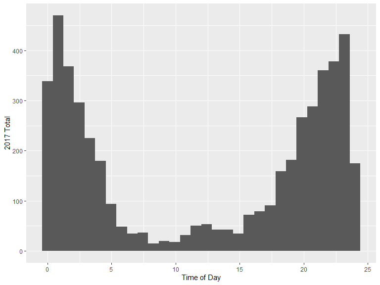

```r
ggplot(shotspot, aes(x=exact_time)) +
  geom_histogram() +
  xlab("Time of Day") +
  ylab("2017 Total")
```

## Shotspotter data - Manually set breaks

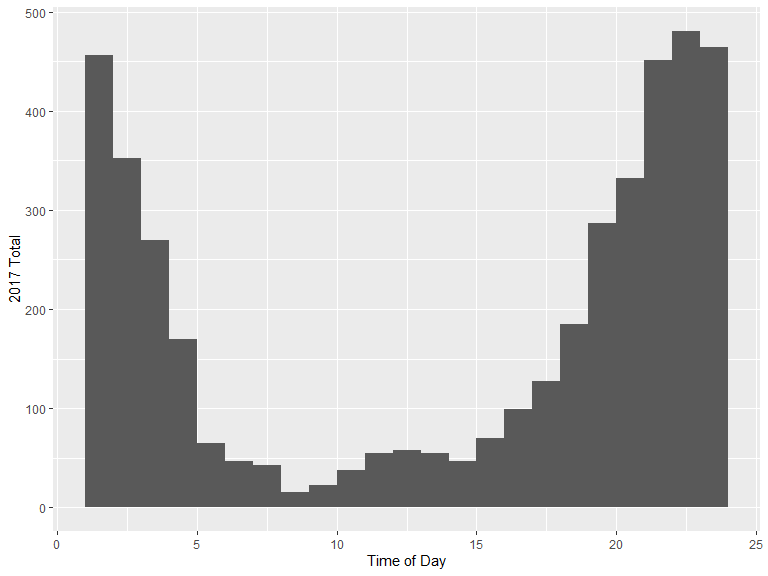

```r
ggplot(shotspot, aes(x=exact_time)) +
  geom_histogram(breaks = c(1,2,3,4,5,6,7,8,9,10,11,12,13,14,15,16,17,18,19,20,21,22,23,24)) +
  xlab("Time of Day") +
  ylab("2017 Total")
```

## Can we fix the weird truncation?

- Let’s create a new variable called ‘time_til_midnight’

```r
shotspot <- shotspot %>% mutate(time_til_midnight = ifelse(exact_time>12,exact_time-24,exact_time))
```

## Now plot our new variable

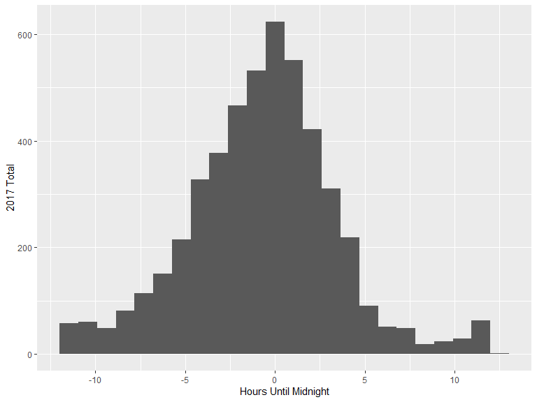

```r
ggplot(shotspot, aes(x=time_til_midnight)) +
  geom_histogram(bins=24) +
  xlab("Hours Until Midnight") +
  ylab("2017 Total")
```

## Another Option - Density Plot

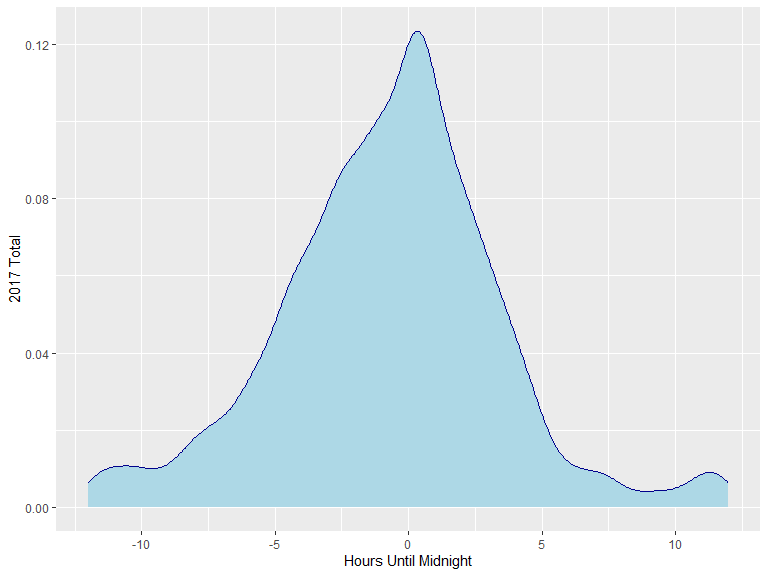

```r
ggplot(shotspot, aes(x=time_til_midnight)) +
  geom_density(color="darkblue",fill="lightblue") +
  xlab("Hours Until Midnight") +
  ylab("2017 Total")
```

## Does the density change from summer to winter?

- Create an indicator for “summer”

```r
shotspot <- shotspot %>%
  mutate(Summer = month >= 4 & month <=9)
```

## Now plot

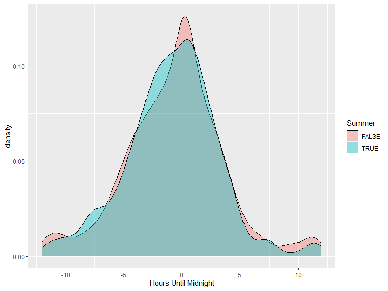

```r
ggplot(shotspot, aes(x=time_til_midnight, fill=Summer)) +
  geom_density(alpha=.4) +
  xlab("Hours Until Midnight")
```

## Line graph - great for plotting an outcome over time

- How many goals did the leading NHL scorer get each year?

```r
nhl_max <- haven::read_dta("NHL Master Dataset.dta") %>%
  group_by(year) %>%
  summarise(max_goals = max(Goals))
```

## Plot over time

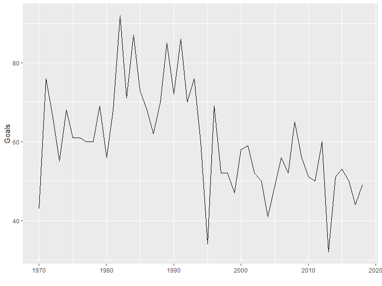

```r
ggplot(nhl_max) +
  geom_line(aes(y=max_goals,x=year)) +
  ylab("Goals") +
  xlab("")
```

## Bar Graph - scoring titles since 1970

- Someone walk me through what’s going on below

```r
rocket_richards <- haven::read_dta("NHL Master Dataset.dta") %>%
  group_by(year) %>%
  mutate(max_goals = max(Goals)) %>%
  filter(Goals == max_goals) %>%
  mutate(title = 1) %>%
  group_by(Name)  %>%
  mutate(titles = sum(title)) %>%
  filter(titles > 1)
```

## Number of scoring titles 1970-2018 (Minimum of 2)

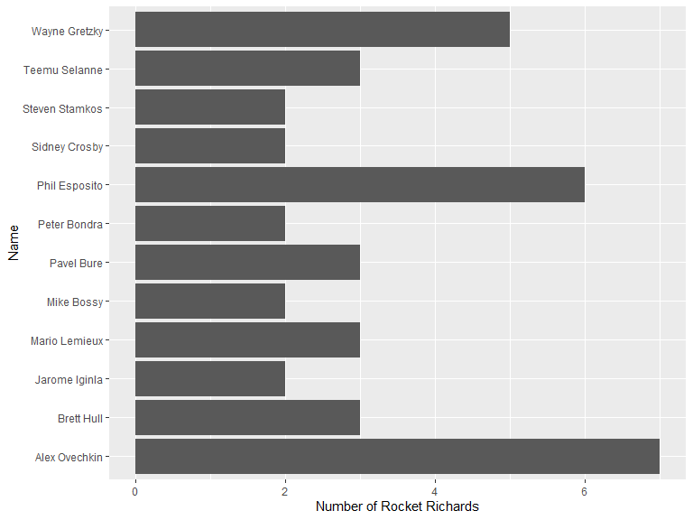

```r
ggplot(rocket_richards, aes(y=Name)) +
  geom_bar() +
  xlab("Number of Rocket Richards")
```

## Let’s make some maps!

- R has a lot of great mapping packages
  - Make it easy to make cool maps without GIS skills
- We will focus on ‘usmap’ package

```r
#install.packages('usmap')
library(usmap)
```

## What do we need?

- Something that varies across states/counties
- FIPS code (variable should be called ‘fips’)
  - That’s it!

## Here is COVID cases in 2020 by county

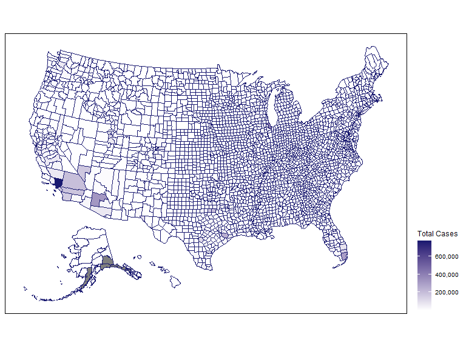

## Here is the code for this

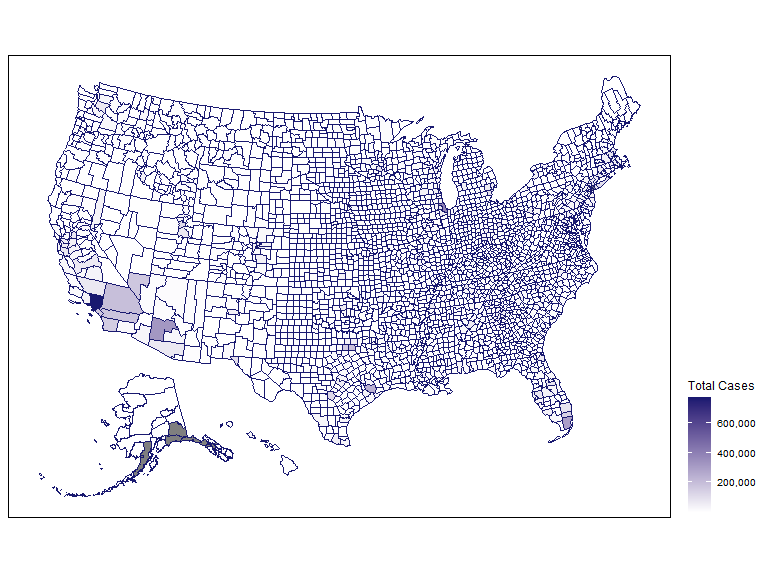

```r
plot_usmap(data = covid_2020, values = "cases",  color = "midnightblue", labels=FALSE) +
  scale_fill_continuous( low = "white", high = "midnightblue",
                         name = "Total Cases", label = scales::comma) +
  theme(legend.position = "right") +
  theme(panel.background = element_rect(colour = "black"))
```

## One solution - log(cases)

- why might this help?

```r
covid_2020 <- covid_2020 %>%
  mutate(log_cases = log(cases))
```

## Log COVID cases by county

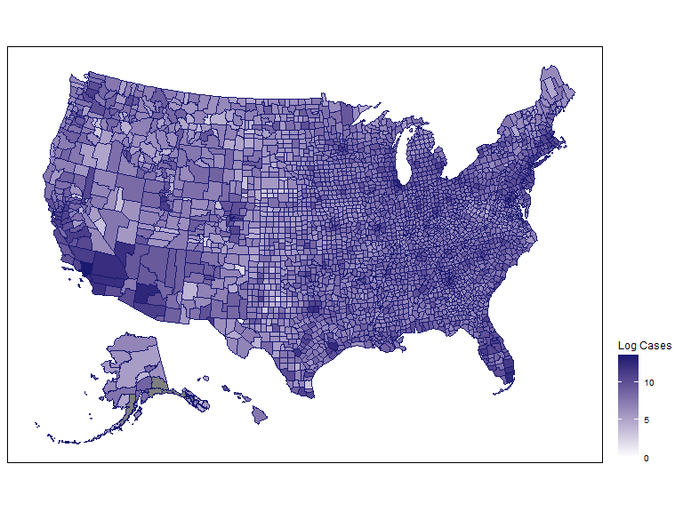

```r
plot_usmap(data = covid_2020, values = "log_cases",  color = "midnightblue", labels=FALSE) +
  scale_fill_continuous( low = "white", high = "midnightblue",
                         name = "Log Cases", label = scales::comma) +
  theme(legend.position = "right") +
  theme(panel.background = element_rect(colour = "black"))
```

[figure not shown]

```r
plot_usmap(data = covid_2020, values = "cases_per100k",  color = "midnightblue", labels=FALSE) +
  scale_fill_continuous( low = "white", high = "midnightblue",
                         name = "Cases per 100k", label = scales::comma) +
  theme(legend.position = "right") +
  theme(panel.background = element_rect(colour = "black"))
```

## We can also look at just Ohio (or any states we want)

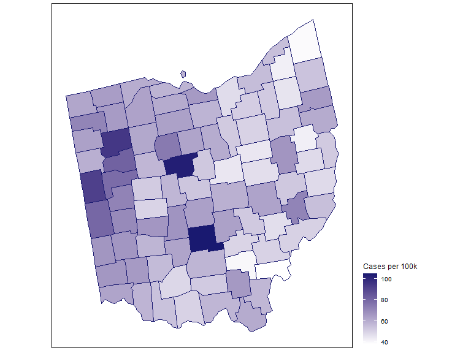

```r
plot_usmap(data = covid_2020, values = "cases_per100k", include = c("OH"),
           color = "midnightblue", labels=FALSE) +
              scale_fill_continuous( low = "white", high = "midnightblue",
                         name = "Cases per 100k", label = scales::comma) +
              theme(legend.position = "right") +
              theme(panel.background = element_rect(colour = "black"))
```

## We can also do this at the state level

- Just need fips variable to be state level
- Let’s go back to our BRFSS data and see which states exercise the most

```r
brfss_21 <- haven::read_dta("brfss_21_class_data.dta")
brfss_exercise <- brfss_21 %>%
  group_by(state_fips) %>%
  summarise(exercise = mean(exer_last_30)) %>%
  rename(fips = state_fips)
```

## State-level map using BRFSS exercise data

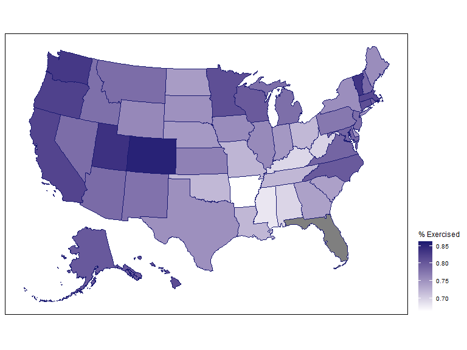

## Coding exercise

- Make a map that shows the effect of *Dobbs vs. Jackson* on abortion access by county
- Use “myers_clinic_distance_may24.dta”
- **distance_origintodest** gives driving distance to nearest clinic
- For each county, calculate the difference in the average distance in 2021 vs. 2023
- Exclude AK and HI

## What I would do…

- Calculate avg. distance for 2021 using summarise()
- Repeat for 2023
- Merge by county
- Don’t forget to rename origin_fips_code to **fips**

## Solution

```r
abortion_distance_21 <- abortion_distance %>%
  filter(year == 2021, origin_state != "AK", origin_state != "HI") %>%
  group_by(origin_fips_code) %>%
  summarise(distance = mean(distance_origintodest)) %>%
  mutate(fips = origin_fips_code)

abortion_distance_23 <- abortion_distance %>%
  filter(year == 2023, origin_state != "AK", origin_state != "HI") %>%
  group_by(origin_fips_code) %>%
  summarise(distance = mean(distance_origintodest)) %>%
  mutate(fips = origin_fips_code)

dist_change <- merge(abortion_distance_21, abortion_distance_23, by = c("fips")) %>%
  mutate(dobbs_change = distance.y - distance.x)
```

## Solution part 2

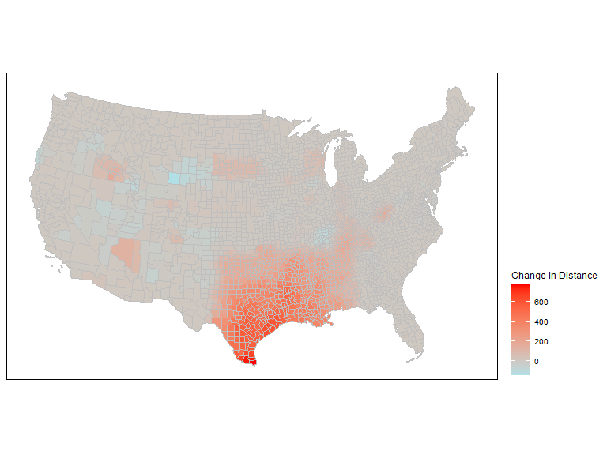

```r
plot_usmap(data = dist_change, values = "dobbs_change", exclude = c("AK", "HI"),
           color = "grey", labels=FALSE) +
  scale_fill_continuous( low = "powderblue", high = "red",
                         name = "Change in Distance", label = scales::comma) +
  theme(legend.position = "right") +
  theme(panel.background = element_rect(colour = "black"))
```

## Truncate at 200 miles

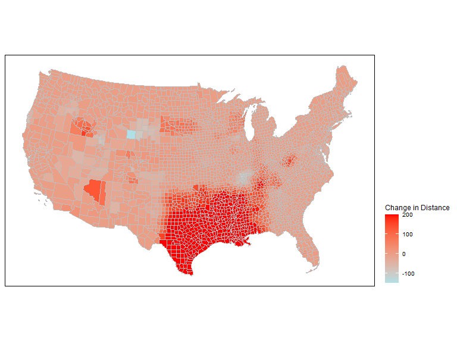

```r
dist_change <- dist_change %>%
  mutate(dobbs_change_trunc=ifelse(dobbs_change<200,dobbs_change,200))

plot_usmap(data = dist_change, values = "dobbs_change_trunc", exclude = c("AK", "HI"),
           color = "grey", labels=FALSE) +
  scale_fill_continuous( low = "powderblue", high = "red",
                         name = "Change in Distance", label = scales::comma) +
  theme(legend.position = "right") +
  theme(panel.background = element_rect(colour = "black"))
```

## Bonus exercise

- Plot the distribution of the change in distance from 2021 to 2023, using either a histogram or density plot

## Histogram

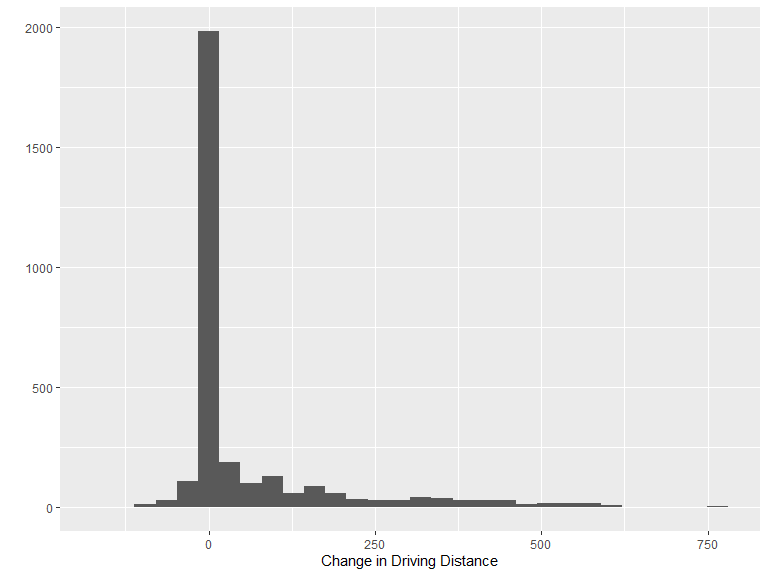

```r
ggplot(dist_change, aes(x=dobbs_change)) +
  geom_histogram() +
  xlab("Change in Driving Distance") +
  ylab("")
```

## Density

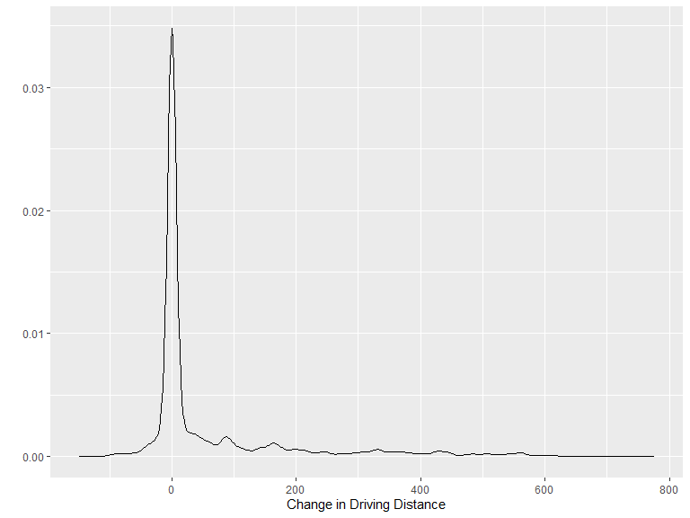

```r
ggplot(dist_change, aes(x=dobbs_change)) +
  geom_density() +
  xlab("Change in Driving Distance") +
  ylab("")
```